# Analysis of Stock Market Data of Vaccine Companies in COVID19 Pandemic

Mert Taşdemir, Yasin Doğa Özkütük, Gizem Miçooğulları

2022-01-19

Abstract

# Introduction

On 31 December 2019, WHO was informed of cases of pneumonia of unknown cause in Wuhan City, China. A novel corona virus was identified as the cause by Chinese authorities on 7 January 2020 and was temporarily named *2019-nCoV. Whenever virus spread to the other countries, it has named **COVID19* and WHO announced this disease as global pandemic in March 11, 2020. This pandemic has become worst disease since the Spanish Flu. As expected, almost each part of industry has affected negatively. Especially in stock prices of transportation and food services significant decrease can be observed. For instance, while Lufthansa Airlines has stock price $16.41$ in December 1, 2019 this value became $8.16$ in April 1, 2020. To summarize, 2020 became an unlucky year for many sector. However, last days of December 2020 some health companies such as Moderna Inc., BioNTech and AstraZeneca(University of Oxford) announced their success in development of COVID19 vaccine. Henceforth in 2021 both society and global economy took a sigh of relief. Based on affects of pandemic in stock markets, we encouraged to make this project. In this project, statistical analysis and comparison between stock price data of three vaccine company Moderna Inc., Pfizer& BioNTech and AstraZeneca by splitting data into critical dates such as authorization date in a region or starting dates of phase 1,2,3 for those companies will be performed. It is planned to take the data from a time interval from January 1, 2020 to October 1, 2021. Additionally, some data visualization techniques will be used during this project in order to provide a clear explanation of our work. Statistical analyses are also added.

[Yahoo Finance](https://finance.yahoo.com/), which is one of the well-known finance data providers will be source of data sets of the project. As explained, three vaccine companies will be considered in whole analysis and comparisons. Reader could be curious about the why only BioNTech will be included while Pfizer excluded. The main reason is to prevent confusions. It is obvious that stock prizes of Pfizer and BioNTech are positively correlated. The data sets has taken as csv files and converted to the regular xlsx files. Each data set has been taken from NasdaqGS in terms of USD currency.

The team GDM has not made any significant change in the project plan. The plan of team is same as in the proposal. Besides, there is some revisions too. Team has decided to include a geographical visualization techniques too. Probably, final report will consist of a map of a certain region that illustrates preferred vaccine among the companies that included in this project. We use the following libraries throughout the report.

```r
library(rmarkdown)
library(readxl)
library(tidyverse)
library(knitr)
library(ggridges)
```

# Analyses and Visualizations for BioNTech, Moderna Inc. and AstraZeneca

In this section, we give visualizations and statistical comments of each vaccine company seperately.

## BioNTech

[BioNTech](https://biontech.de/) ( short for Biopharmaceutical New Technologies) is a German biotechnology company based in Mainz that develops and manufactures active immunotherapies for patient-specific approaches to the treatment of diseases. Among the society, this company known for developing mRNA type vaccine for COVID19. The stock data of BioNTech that project aims to consider is closing values of stock prices of days in range January 1,2020 and October 1, 2021. The data set imported from [Yahoo Finance](https://finance.yahoo.com/quote/BNTX/history?p=BNTX) and it has cleaned from unwanted data.

```r
biontechdata=read_excel("biontech.xlsx")
biontechdata= biontechdata %>% select(Date | Close)
```

Moreover critical dates are listed below, these dates has been taken from news websites.

```r
cridateseventsbiontech=read_excel("criticaldatesbiontech.xlsx")
cridateseventsbiontech %>% kable()
```

| Date | Event |
| --- | --- |
| 2020-04-23 | First Volunteer in Germany Receives Vaccine |
| 2020-05-05 | First Volunteer in United States Receives Vaccine |
| 2020-07-27 | Phase 2 and 3 are started |
| 2020-12-02 | Authorized in United Kingdom |
| 2020-12-11 | Authorized in United States |
| 2020-12-21 | Authorized in European Union |
| 2021-08-23 | FDA grants full approval |

As authorization dates are close to each other we prefer to take the date 2020-12-21 which is authorization date of BioNTech in European Union in furher analysis. Likewise, we choose the date 2020-05-05 which corresponds to the date of first voluntary vaccination in United States. Therefore we consider the following critical date table in remaining part of this report in statistical analysis.

```r
cridateseventsbiontech %>%
  filter(Date==cridateseventsbiontech$Date[2] |Date==cridateseventsbiontech$Date[3] |
           Date==cridateseventsbiontech$Date[6] |Date==cridateseventsbiontech$Date[7]) %>%
  kable()
```

| Date | Event |
| --- | --- |
| 2020-05-05 | First Volunteer in United States Receives Vaccine |
| 2020-07-27 | Phase 2 and 3 are started |
| 2020-12-21 | Authorized in European Union |
| 2021-08-23 | FDA grants full approval |

The following graph illustrates closed prices of stock data of BioNTech in time interval, moreover critical dates can be seen in red points.

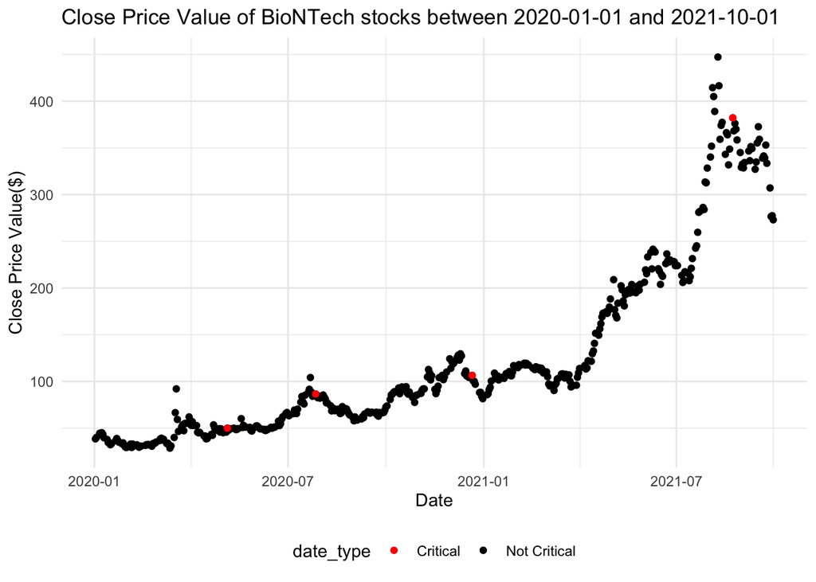

```r
biontechdata$Date <- as.Date(biontechdata$Date)
newcridates=as.Date(c("2020-05-05","2020-07-27","2020-12-21","2021-08-23"))
biontechdata=biontechdata %>%
  mutate(date_type=case_when(biontechdata$Date
                             %in% newcridates ~ "Critical", TRUE ~ "Not Critical"))
highlight=biontechdata %>%
  filter(date_type=="Critical")
closevalue=ggplot(biontechdata, aes(x = Date, y = Close))+
  geom_point()+
  geom_point(data=highlight,aes(x = Date, y = Close,color=date_type))+
  labs(x = "Date", y="Close Price Value($)",
       title= "Close Price Value of BioNTech stocks between 2020-01-01 and 2021-10-01")+
  scale_color_manual(values = c("Critical" = "red",
                                "Not Critical" = "black"))
closevalue+
  theme_minimal()+
  theme(legend.position = "bottom")
```

The time interval we consider can be divided by four sub-intervals by considering critical dates. Henceforward, those sub-intervals will be called “$i^{th}$” period of stock data. The following bar chart contains mean stock close price data at each section.

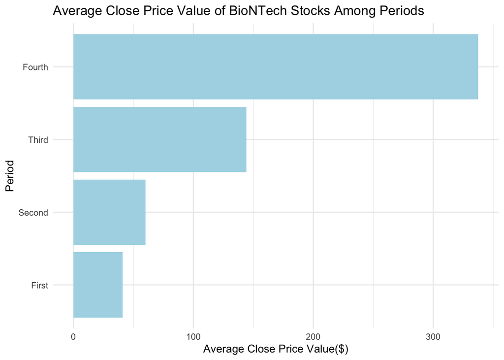

```r
biontechdata = biontechdata %>%
  mutate(Period=case_when(Date <= "2020-05-05" ~ 1,
                           Date > "2020-05-05" & Date <= "2020-07-27" ~ 2,
                           Date > "2020-07-27" & Date <= "2021-08-23" ~ 3,
                           Date > "2021-08-23" ~ 4 ))
avg=biontechdata %>%
  group_by(Period) %>%
  summarise(Average=mean(Close))
ggplot(avg,aes(x= Average,y=factor(Period)))+
  geom_col(fill="lightblue")+
  scale_y_discrete(labels=c("First","Second","Third","Fourth"))+
  labs(x = "Average Close Price Value($)",
       y="Period",
       title= "Average Close Price Value of BioNTech Stocks Among Periods")+
  theme_minimal()+
  theme(legend.position = "bottom")
```

It can be seen that average value of close value of stock prize has been increased in all periods. Therefore, it can be said that each successful event in vaccine development has increased the stock value of BioNTech. To prepare our data set into statistical tests, we need to determine the amount of its closeness to the normal distribution. We can measure this by quantile-quantile plot of each period.

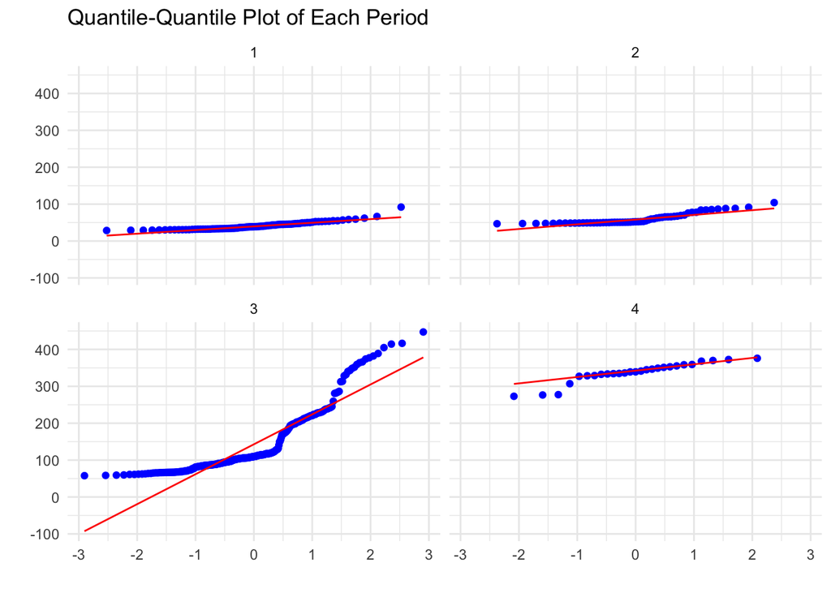

```r
ggplot(biontechdata,aes(sample=Close))+
  stat_qq(color="blue")+
  stat_qq_line(color="red")+
  facet_wrap(~Period)+
  labs(x = " ", y=" ",
       title= "Quantile-Quantile Plot of Each Period")+
  theme_minimal()+
  theme(legend.position = "bottom")
```

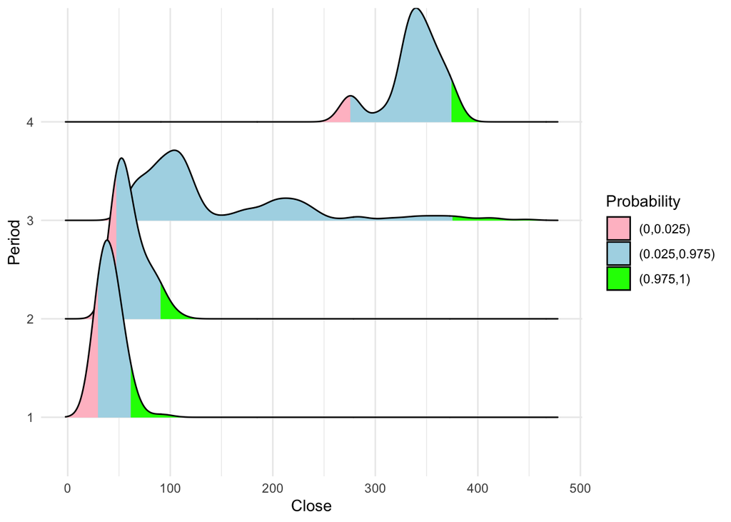

```r
ggplot(biontechdata, aes(x= Close, y= factor(Period), fill=factor(stat(quantile))))+
  stat_density_ridges(geom="density_ridges_gradient",
                                                                                                         calc_ecdf=T, quantiles
                      =c(0.025,0.975))+ylab("Period")+
  scale_fill_manual(name="Probability",
                    values=c("pink","lightblue","green"),
                    labels=c("(0,0.025)","(0.025,0.975)","(0.975,1)"))+
  theme_minimal()
```

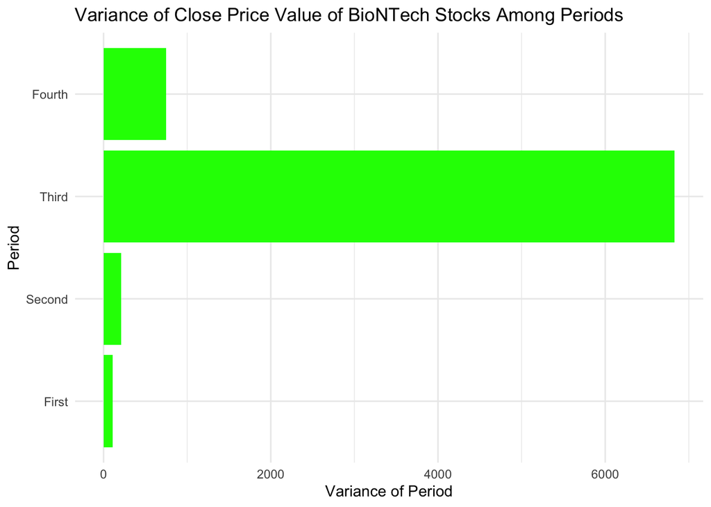

```r
variance=biontechdata %>%
  group_by(Period) %>%
  summarise(Variance=var(Close))
ggplot(variance,aes(x=Variance,y=factor(Period)))+
  geom_col(fill="green")+
  scale_y_discrete(labels=c("First","Second","Third","Fourth"))+
  labs(x = "Variance of Period",
       y="Period",
       title= "Variance of Close Price Value of BioNTech Stocks Among Periods")+
  theme_minimal()+
  theme(legend.position = "bottom")
```

It is safe to say that third period has significantly wide range. The main reason of this is it has long time range compared to others. On the other hand it can be expected that in real world long term data includes chaos.

## Moderna Inc.

[Moderna Inc.](https://www.Moderna%20Inc.tx.com/) (Moderna Inc. Covid-19 vaccine producer) Moderna Inc., Inc. operates as a clinical stage biotechnology company. The Company focuses on the discovery and development of messenger RNA therapeutics and vaccines. Moderna Inc. Inc. which is based in Cambridge, Massachusetts, develops mRNA medicines for infectious, immuno-oncology, and cardiovascular diseases. Among the society, this company known for developing mRNA type vaccine for COVID19. The stock data of Moderna Inc. Inc. that project aims to consider the closing values of stock prices of days in range January 1,2020 and October 1, 2021. The Moderna Inc. Inc stock values have been imported from [Yahoo Finance](https://finance.yahoo.com/quote/MRNA?p=MRNA&.tsrc=fin-srch) and the unnecessary data have been cleaned from the data and the charts.

```r
ModernaData = read_excel("Moderna.xlsx")
ModernaData = ModernaData %>% select(Date | Close)
```

The news that have had high impact on stock prices, have been marked(These dates were found in internet news such as NYTimes, Bloomberg etc.).

```r
criticalDatesModerna = read_excel("criticalDateModerna.xlsx")
criticalDatesModerna %>% kable()
```

| Date | Event |
| --- | --- |
| 2020-03-16 | First Volunteer in America receives first vax |
| 2020-07-27 | Phase 2 & 3 have started |
| 2020-12-02 | Authorized in UK |
| 2020-12-18 | Authorized in USA |
| 2021-01-06 | Authorized in EU |
| 2021-12-18 | FDA grants full approval |

We will be choosing 5 critical dates, which has an unusual increase due to the news. These dates will be the date of “The first Volunteer in USA recieves the vaccine” - 16 March 2020. The second critical date will be the date when “Phase 2 & 3 start”. The other three critical dates will be the dates of Authorizations respectively in UK, USA and EU.

```r
criticalDatesModerna %>%
  filter(Date == criticalDatesModerna$Date[1] |
           Date == criticalDatesModerna$Date[2] | Date== criticalDatesModerna$Date[3] |
           Date == criticalDatesModerna$Date[4] |
           Date == criticalDatesModerna$Date[5]) %>%
  kable()
```

| Date | Event |
| --- | --- |
| 2020-03-16 | First Volunteer in America receives first vax |
| 2020-07-27 | Phase 2 & 3 have started |
| 2020-12-02 | Authorized in UK |
| 2020-12-18 | Authorized in USA |
| 2021-01-06 | Authorized in EU |

The following graph illustrates closing prices of “Moderna Inc. Inc” in time interval, where critical dates can be seen in red points.

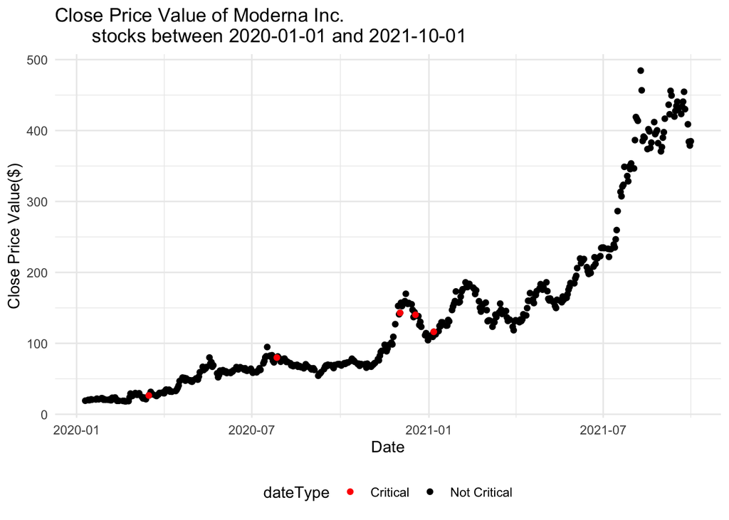

```r
ModernaData$Date <- as.Date(ModernaData$Date)
newCriticalDates=as.Date(c("2020-03-16","2020-07-27",
                           "2020-12-02","2020-12-18",
                           "2021-01-06"))
ModernaData=ModernaData %>%
  mutate(dateType=case_when(ModernaData$Date %in%
                              newCriticalDates ~ "Critical",
                            TRUE ~ "Not Critical"))
highLight=ModernaData %>%
  filter(dateType=="Critical")
closeValue=ggplot(ModernaData, aes(x = Date, y = Close))+
  geom_point()+
  geom_point(data=highLight,aes(x = Date, y = Close,color=dateType))+
  labs(x = "Date", y="Close Price Value($)",
       title= "Close Price Value of Moderna Inc.
       stocks between 2020-01-01 and 2021-10-01")+
  scale_color_manual(values = c("Critical" = "red",
                                "Not Critical" = "black"))
closeValue+theme_minimal()+
theme(legend.position = "bottom")
```

According to the chart above, the effect of first two critical news can not be observed clearly. Even though stock price during announcement of the event “First volunteer got vaccinated in USA” was significantly increasing from 21.3 to 26.5 one can not see this increment in the graph above. The similar confusion can be seen at the second critical date. Although the price of stock was increasing by 10%, in the graph it seems to be decreasing. Other three critical dates have not such confusions, the price change seems to be accurate.

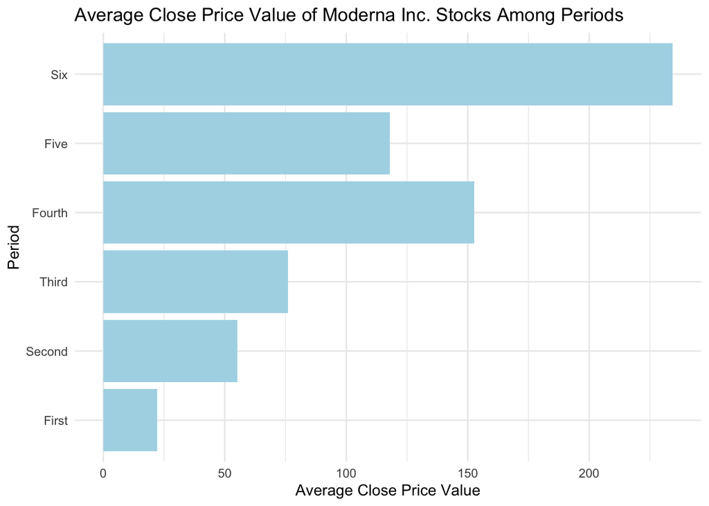

```r
ModernaData = ModernaData %>%
  mutate(Period=case_when(Date <= "2020-03-16" ~ 1,
                           Date > "2020-03-16" & Date <= "2020-07-27" ~ 2,
                           Date > "2020-07-27" & Date <= "2020-12-02" ~ 3,
                           Date > "2020-12-02" & Date <= "2020-12-18" ~ 4,
                           Date > "2020-12-18" & Date <= "2021-01-06" ~ 5,
                           Date > "2021-01-06" & Date <= "2021-12-18" ~ 6))
average=ModernaData %>%
  group_by(Period) %>%
  summarise(Average=mean(Close))
ggplot(average,aes(x= Average,y=factor(Period)))+
  geom_col(fill="lightblue")+
  scale_y_discrete(labels=c("First","Second","Third",
                            "Fourth", "Five", "Six"))+
  labs(x = "Average Close Price Value",
       y="Period",
       title= "Average Close Price Value of Moderna Inc. Stocks Among Periods")+
  theme_minimal()+
  theme(legend.position = "bottom")
```

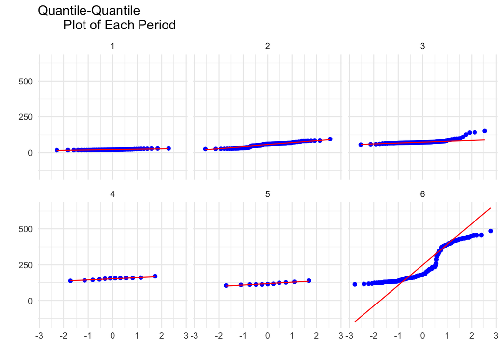

```r
ggplot(ModernaData,aes(sample=Close))+
  stat_qq(color="blue")+
  stat_qq_line(color="red")+
  facet_wrap(~Period)+
  labs(x = " ", y=" ",title= "Quantile-Quantile
       Plot of Each Period")+
  theme_minimal()+
  theme(legend.position = "bottom")
```

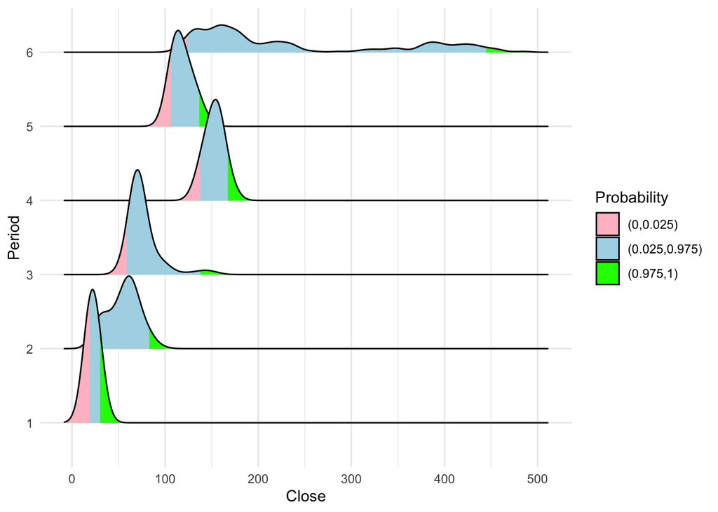

```r
ggplot(ModernaData, aes(x= Close, y= factor(Period),
                        fill=factor(stat(quantile))))+
  stat_density_ridges(geom="density_ridges_gradient",
                                                                                                          calc_ecdf=T, quantiles = c(0.025,0.975))+
  ylab("Period")+
  scale_fill_manual(name="Probability",
                    values=c("pink","lightblue","green"),
                    labels=c("(0,0.025)","(0.025,0.975)","(0.975,1)"))+
  theme_minimal()
```

The density plot asserts preliminary information about statistical tests. First, fourth and fifth periods fit into a normal distribution clearly, however second and third periods have some unsymmetrical trends, but in anyway one can make statistical tests on them. In sixth period, there is wide range for close valuse distribution, hence it has wide $95%$ confidence interval. However, thanks to the quantile-quantile plot, preliminary statistical tests are applicable. This density plot gives clue about variances of periods. The following bar chart indicates variances of each period.

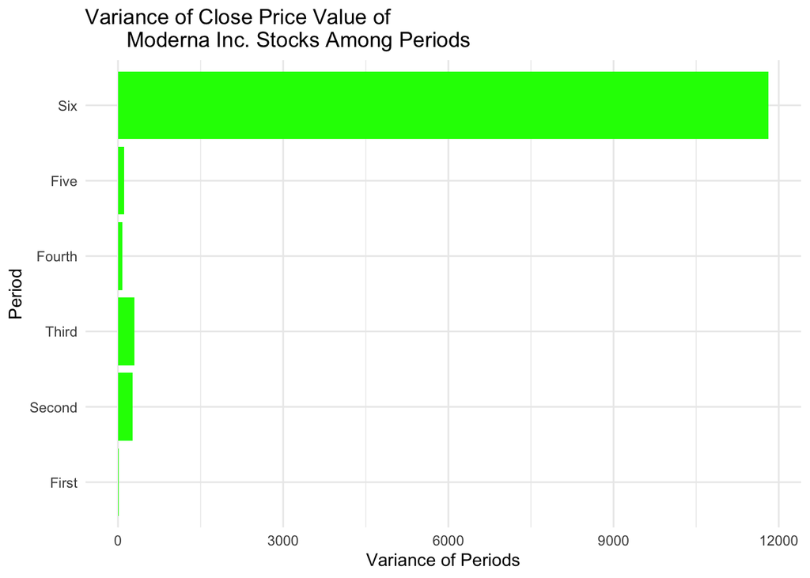

```r
varians=ModernaData %>%
  group_by(Period) %>%
  summarise(Variance=var(Close))
ggplot(varians,aes(x=Variance,y=factor(Period)))+
  geom_col(fill="green")+
  scale_y_discrete(labels=c("First","Second","Third",
                            "Fourth", "Five", "Six"))+
  labs(x = "Variance of Periods", y="Period",
       title= "Variance of Close Price Value of
       Moderna Inc. Stocks Among Periods")+
  theme_minimal()+
  theme(legend.position = "bottom")
```

According to the chart, clearly sixth period has comparatively large variance. The other periods has reasonable variances compared to the sixth period.

## AstraZeneca

AstraZeneca plc is a British-Swedish multinational pharmaceutical and biotechnology company with its headquarters at the Cambridge Biomedical Campus in Cambridge, England. It has a portfolio of products for major diseases in areas including oncology, cardiovascular, gastrointestinal, infection, neuroscience, respiratory, and inflammation. It has been involved in developing the Oxford-AstraZeneca COVID-19 vaccine.

The company was founded in 1999 through the merger of the Swedish Astra AB and the British Zeneca Group. Since the merger it has been among the world’s largest pharmaceutical companies and has made numerous corporate acquisitions, including Cambridge Antibody Technology (in 2006), MedImmune (in 2007), Spirogen (in 2013) and Definiens (by MedImmune in 2014).

AstraZeneca has a primary listing on the London Stock Exchange and is a constituent of the FTSE 100 Index. It has secondary listings on Nasdaq OMX Stockholm, Nasdaq New York, the Bombay Stock Exchange and on the National Stock Exchange of India.

The stock price of AstraZeneca was imported from Yahoo Finance and cleaned from unnecessary and untidy data.

```r
  astrazenecadata=read_excel("astrazeneca.xlsx")
  astrazenecadata=astrazenecadata %>% select(Date | Close)
```

The critical dates have been chosen according to the news about AstraZeneca and listed below.

```r
  datesAstrazeneca=as.Date(c("2020-04-23","2020-05-22","2020-08-31",
                     "2020-12-3020","21-01-29","2021-03-25","2021-04-07"))
eventsAstrazeneca=c("First  volunteer given vaccine",
                    "Phase 2","US phase 3 trial begins","Authorized in Uk",
                    "Authorized in EU",
                    "Reuses data after US",
                    "EMA funds possible casval link between vaccine
and rare clotting events")
cridatesAstraZeneca=tibble(datesAstrazeneca,eventsAstrazeneca)
cridatesAstraZeneca %>% rename("Date"=datesAstrazeneca ,
                               "Event"=eventsAstrazeneca) %>%
  kable()
```

[output not shown]

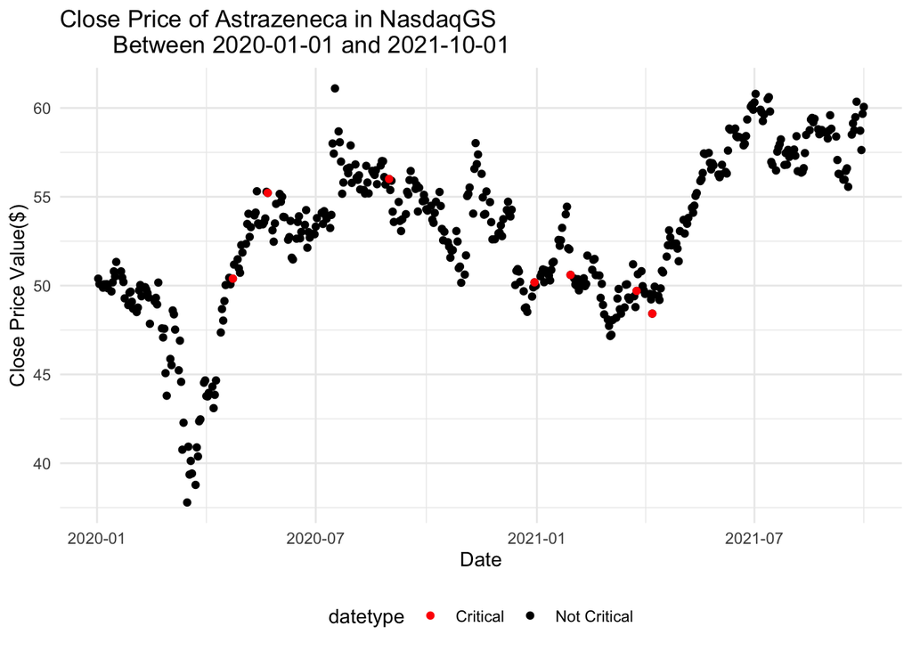

```r
astrazenecadata$Date <- as.Date(astrazenecadata$Date)
newCriticalDates=as.Date(c("2020-04-23","2020-05-22",
                           "2020-08-31","2020-12-30",
                           "2021-01-29" , "2021-03-25", "2021-04-07"))
astrazenecadata=astrazenecadata %>%
  mutate(datetype=case_when(astrazenecadata$Date %in%                                                                   newCriticalDates ~ "Critical",
                               TRUE ~ "Not Critical"))
 highLight=astrazenecadata %>%
     filter(datetype=="Critical")
 closeValue=ggplot(astrazenecadata,
                   aes(x = Date, y = Close))+
     geom_point()+
     geom_point(data=highLight,
                aes(x = Date, y = Close,color=datetype))+
     labs(x = "Date",
          y="Close Price Value($)",
          title= "Close Price of Astrazeneca in NasdaqGS
        Between 2020-01-01 and 2021-10-01")+
     scale_color_manual(values = c("Critical" = "red",
                                   "Not Critical" = "black"))
 closeValue+theme_minimal()+
   theme(legend.position = "bottom")
```

Obviously, the minimum and maximum values in the graph are not distant. The stock prices of the AstraZeneca do not seem to be affected by the vaccine related news. The chosen first five critical points are in favor of the stock price, however their impact is low. Furthermore the recent reports of complains from United States and European Medicines Agency(EMA) clotting issues do not seem to decrease value of the company significantly. Therefore, we expect to see averages of periods are close to each other. The following bar chart contains information about means of periods separately.

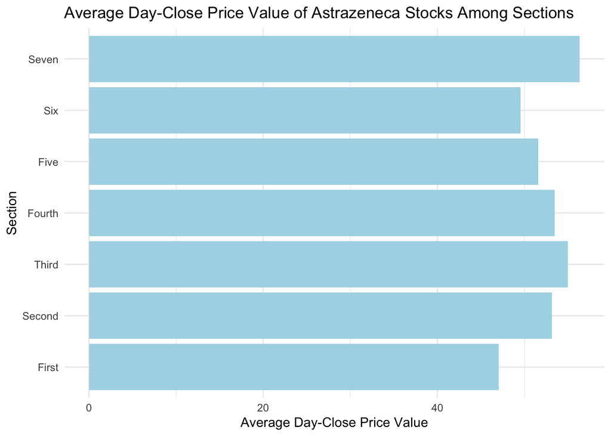

```r
 astrazenecadata = astrazenecadata %>%
     mutate(Section=case_when(Date <= "2020-04-23" ~ 1,
                              Date > "2020-04-23" & Date <= "2020-05-22" ~ 2,
                              Date > "2020-05-22" & Date <= "2020-08-31" ~ 3,
                              Date > "2020-08-31" & Date <= "2020-12-30" ~ 4,
                              Date > "2020-12-30" & Date <= "2021-01-29" ~ 5,
                              Date > "2021-01-29" & Date <= "2021-03-25" ~ 6,
                              Date > "2021-03-25" ~ 7))
average=astrazenecadata %>%
     group_by(Section) %>%
     summarise(Average=mean(Close))
ggplot(average,aes(x= Average,y=factor(Section)))+
     geom_col(fill="lightblue")+
     scale_y_discrete(labels=c("First","Second","Third",
                               "Fourth", "Five", "Six", "Seven"))+
     labs(x = "Average Day-Close Price Value",
          y="Section",
          title= "Average Day-Close Price Value of Astrazeneca Stocks Among Sections")+
     theme_minimal()+
     theme(legend.position = "bottom")
```

As expected, average stock price of periods do not apart. Henceforth, their tendency as distribution expected to close. The following quantile-quantile plot measures their closeness to a normal distribution.

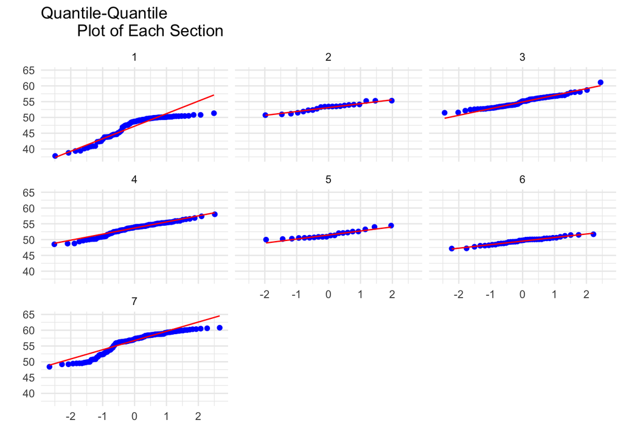

```r
ggplot(astrazenecadata,aes(sample=Close))+
     stat_qq(color="blue")+
     stat_qq_line(color="red")+
     facet_wrap(~Section)+
     labs(x = " ", y=" ",title= "Quantile-Quantile
        Plot of Each Section")+
     theme_minimal()+
     theme(legend.position = "bottom")
```

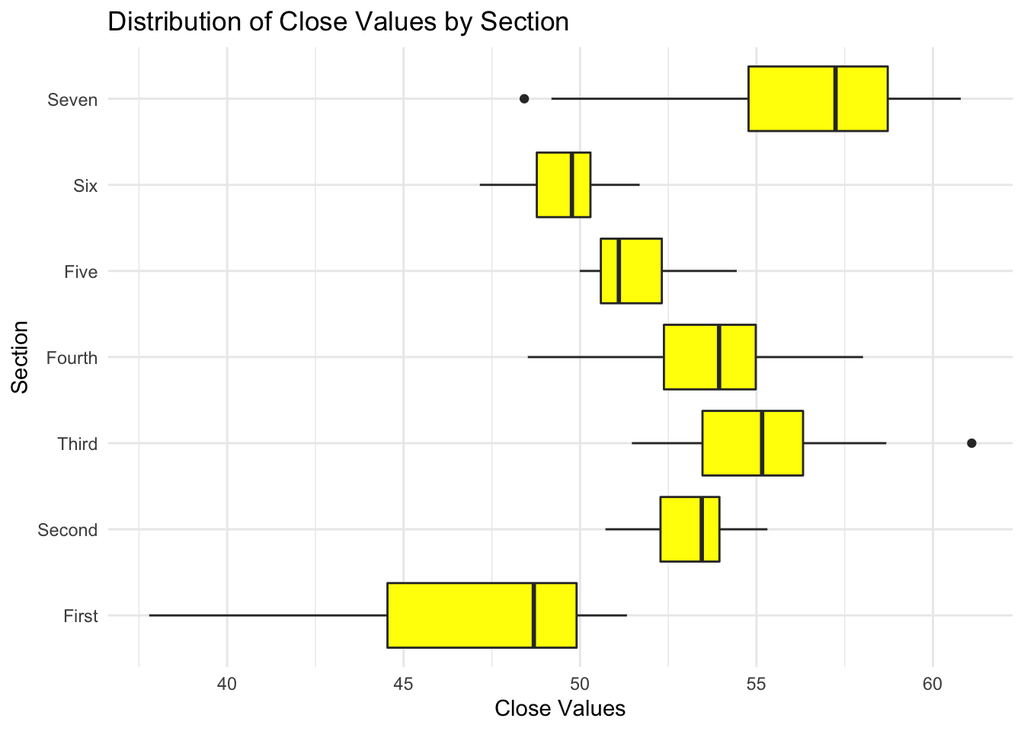

The box plot claims that even though their mean and tendencies are close, variances of each period differs from each other. On the other hand, there are outlier points in third and seventh periods. Moreover, first and seventh periods are expected to have larger variance compared to others. The following bar chart compares variances of each period.

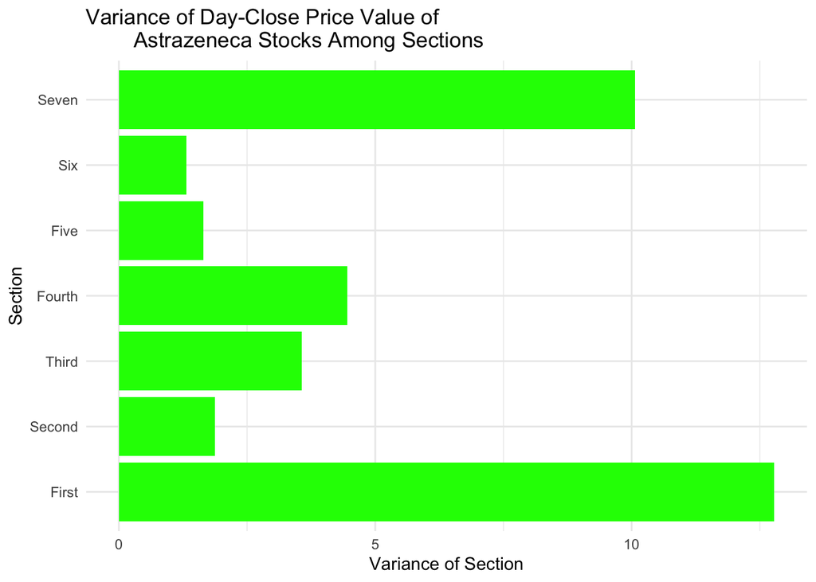

```r
 varians=astrazenecadata %>%
     group_by(Section) %>%
     summarise(Variance=var(Close))
ggplot(varians,aes(x=Variance,y=factor(Section)))+
     geom_col(fill="green")+
     scale_y_discrete(labels=c("First","Second","Third",
                               "Fourth", "Five", "Six", "Seven"))+
     labs(x = "Variance of Section", y="Section",
          title= "Variance of Day-Close Price Value of
        Astrazeneca Stocks Among Sections")+
     theme_minimal()+
     theme(legend.position = "bottom")
```

## Comparison of Vaccine Companies

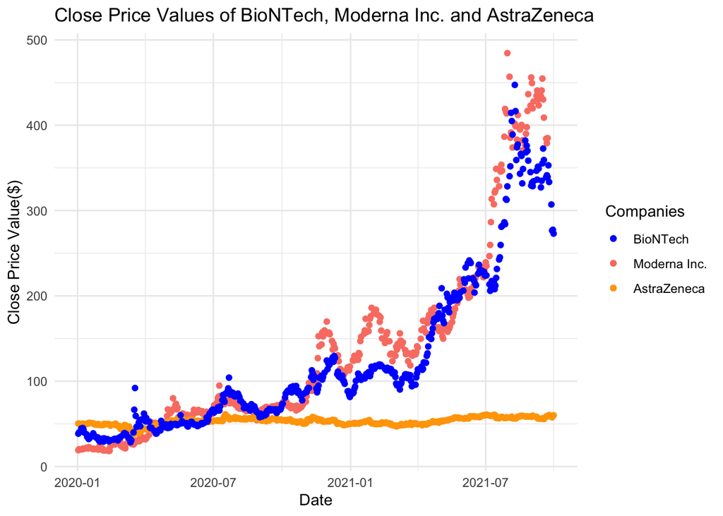

```r
merged_data=read_excel("mergedata.xlsx")
merged_data$Date=as.Date(merged_data$Date)
companies=c("Moderna Inc.","BioNTech","AstraZeneca")
ggplot(merged_data,aes(x=Date, y))+ geom_point(aes(x=Date, y=ModernaClose,color=companies[1]))+geom_point(aes(x=Date, y=AstrazenecaClose,colour=companies[3]))+geom_point(aes(x=Date, y=BiontechClose,colour=companies[2]))+labs(title = "Close Price Values of BioNTech, Moderna Inc. and AstraZeneca", x="Date",y="Close Price Value($)",colour=" Companies")+scale_color_manual(values =c("BioNTech" = "blue", "Moderna Inc." = "salmon", "AstraZeneca"="orange"))+theme_minimal()
```

```r
biontech_first_volunteer=biontechdata  %>% filter(Period==1)
moderna_first_volunteer=ModernaData %>% filter(Period==1)
astrazeneca_first_volunteer= astrazenecadata %>% filter(Section==1)
biontech_phase=biontechdata  %>% filter(Period==2)
moderna_phase=ModernaData  %>% filter(Period==2)
astrazeneca_phase= astrazenecadata  %>% filter(Section==2 | Section==3)
biontech_autharization=biontechdata  %>% filter(Period==3)
moderna_authorization=ModernaData  %>% filter(Period==3 | Period==4 | Period==5)
astrazeneca_authorization= astrazenecadata  %>% filter(Section==4 | Section==4)
biontech_FDA=biontechdata %>% filter(Period==4)
astrazeneca_EMA=astrazenecadata %>% filter(Section==7)
```

# Conclusion and Discussions

# References

- [Dataset of BioNTech Stocks](https://finance.yahoo.com/quote/BNTX/)
- [Dataset of Moderna Inc. Stocks](https://finance.yahoo.com/quote/MRNA/)
- [Dataset of AstraZeneca Stocks](https://finance.yahoo.com/quote/AZN/)